# MMN15 - Deep Learning Assignment

**Submitted by:** Roi Argaman  
**ID:** ********

**Date:** 04/01/2026

This notebook contains solutions for three questions:

1. Custom Conv2d Layer Implementation
2. Manual Backpropagation through Convolution
3. Transfer Learning on CIFAR-10 with ResNet-18

## Imports and Setup

```python
import numpy as np
import torch
import torch.nn as nn
import torch.optim as optim
from torch.utils.data import DataLoader
import torchvision
import torchvision.transforms as transforms
from torchvision import models, datasets
import matplotlib.pyplot as plt
from typing import Tuple, List
from collections import defaultdict
from tqdm.notebook import tqdm

# Set random seeds for reproducibility
np.random.seed(42)
torch.manual_seed(42)
if torch.cuda.is_available():
    torch.cuda.manual_seed(42)

# Device configuration
device = torch.device('cuda' if torch.cuda.is_available() else 'cpu')
print(f"Using device: {device}")
```

```
Using device: cpu
```

## Question 1: Custom Conv2d Layer Implementation

**Objective:** Implement a convolution layer as an nn.Module that replicates the core behavior of nn.Conv2d, including stride and padding.

### Custom Conv2d Implementation

This implementation uses only NumPy for the convolution operation while maintaining PyTorch compatibility through nn.Module and nn.Parameter.

```python
import numpy as np
import torch
import torch.nn as nn
from tqdm import tqdm


class CustomConv2d(nn.Module):
    """
    Custom 2D convolution layer implementing the *core forward behavior*
    of torch.nn.Conv2d using explicit sliding-window convolution.
    """

    def __init__(self,in_channels: int = 1,out_channels: int = 1, kernel_size=(1, 1), stride: int = 1, padding: int = 0):
        """
        Args:
            in_channels (int): Number of input channels (C_in)
            out_channels (int): Number of output channels (C_out)
            kernel_size (int or tuple): Kernel size (kH, kW)
            stride (int): Convolution stride (same for height & width)
            padding (int): Zero-padding applied to all sides
        """
        super().__init__()

        # Store configuration
        self.in_channels = int(in_channels)
        self.out_channels = int(out_channels)
        self.stride = int(stride)
        self.padding = int(padding)

        # Normalize kernel_size to a tuple (kH, kW)
        self.kernel_size = (kernel_size, kernel_size)  if isinstance(kernel_size, int) else tuple(kernel_size)
        kH, kW = self.kernel_size

        # Learnable parameters (same shapes as nn.Conv2d)
        # Weight shape: (C_out, C_in, kH, kW)
        self.weight = nn.Parameter(0.01 * torch.randn(out_channels, in_channels, kH, kW))

        # Bias shape: (C_out,)
        self.bias = nn.Parameter(torch.zeros(out_channels))

    def forward(self, x: torch.Tensor) -> torch.Tensor:
        """
        Forward pass of the convolution.

        Args: x (Tensor): Input of shape (B, C_in, H, W)

        Returns: Tensor: Output of shape (B, C_out, H_out, W_out)        """

        # Convert inputs and parameters to NumPy
        # Detach is required because NumPy cannot track autograd graphs
        x_np = x.detach().cpu().numpy()
        w_np = self.weight.detach().cpu().numpy()
        b_np = self.bias.detach().cpu().numpy()

        B, C_in, H, W = x_np.shape
        kH, kW = self.kernel_size

        # Sanity check
        assert C_in == self.in_channels, \
            f"Expected {self.in_channels} input channels, got {C_in}"

        # Apply symmetric zero-padding
        if self.padding > 0:
            p = self.padding
            x_np = np.pad(x_np,((0, 0), (0, 0), (p, p), (p, p)),mode="constant",constant_values=0)
            H += 2 * p
            W += 2 * p

        # Output spatial dimensions (standard Conv2d formula)
        H_out = (H - kH) // self.stride + 1
        W_out = (W - kW) // self.stride + 1

        # Allocate output tensor
        out = np.zeros((B, self.out_channels, H_out, W_out), dtype=x_np.dtype)

        # Explicit convolution via sliding window
        # tqdm is required by the assignment to visualize progress
        for b in tqdm(range(B), desc="CustomConv2d | batch"):
            for oc in range(self.out_channels):
                for i in range(H_out):
                    h_start = i * self.stride
                    for j in range(W_out):
                        w_start = j * self.stride

                        # Extract local receptive field
                        # Shape: (C_in, kH, kW)
                        region = x_np[
                            b,
                            :,
                            h_start:h_start + kH,
                            w_start:w_start + kW
                        ]

                        # Convolution = sum(region ⊙ kernel) + bias
                        out[b, oc, i, j] = (np.sum(region * w_np[oc]) + b_np[oc])

        # Convert back to torch tensor, preserving dtype & device
        return torch.from_numpy(out).to(device=x.device, dtype=x.dtype)
```

### Testing Custom Conv2d vs PyTorch Conv2d

We'll test our custom implementation against PyTorch's built-in Conv2d with various configurations.

```python
def test_conv2d_comparison(in_channels, out_channels, kernel_size, stride, padding, input_shape):
    """
    Test CustomConv2d against PyTorch's Conv2d
    """
    print(f"\n{'='*60}")
    print(f"Testing Configuration:")
    print(f"  Input shape: {input_shape}")
    print(f"  in_channels={in_channels}, out_channels={out_channels}")
    print(f"  kernel_size={kernel_size}, stride={stride}, padding={padding}")
    print(f"{'='*60}")

    # Create random input
    x = torch.randn(*input_shape)

    # Initialize custom layer
    custom_conv = CustomConv2d(in_channels, out_channels, kernel_size, stride, padding)

    # Initialize PyTorch layer with same weights
    pytorch_conv = nn.Conv2d(in_channels, out_channels, kernel_size, stride, padding)

    # Copy weights from custom to pytorch for fair comparison
    with torch.no_grad():
        pytorch_conv.weight.copy_(custom_conv.weight)
        pytorch_conv.bias.copy_(custom_conv.bias)

    # Forward pass
    custom_output = custom_conv(x)
    pytorch_output = pytorch_conv(x)

    # Compare outputs
    max_diff = torch.max(torch.abs(custom_output - pytorch_output)).item()
    mean_diff = torch.mean(torch.abs(custom_output - pytorch_output)).item()

    print(f"\nOutput shape (Custom):  {custom_output.shape}")
    print(f"Output shape (PyTorch): {pytorch_output.shape}")
    print(f"\nMaximum difference: {max_diff:.6e}")
    print(f"Mean difference:    {mean_diff:.6e}")

    if max_diff < 1e-5:
        print("✓ Test PASSED - Outputs match!")
    else:
        print("✗ Test FAILED - Outputs differ significantly!")

    return max_diff < 1e-5
```

#### Run Multiple Test Cases

```python
# Test Case 1: Basic convolution (no stride, no padding)
test1 = test_conv2d_comparison(in_channels=1, out_channels=1, kernel_size=(3, 3), stride=1, padding=0, input_shape=(2, 1, 5, 5))   # batch_size=2, channels=1, height=5, width=5

# Test Case 2: With padding
test2 = test_conv2d_comparison(in_channels=1, out_channels=2, kernel_size=(3, 3), stride=1, padding=1, input_shape=(1, 1, 5, 5))

# Test Case 3: With stride
test3 = test_conv2d_comparison(in_channels=3, out_channels=4, kernel_size=(3, 3), stride=2, padding=0, input_shape=(1, 3, 8, 8))

# Test Case 4: Multiple channels with stride and padding
test4 = test_conv2d_comparison(in_channels=3, out_channels=8, kernel_size=(5, 5), stride=2, padding=2, input_shape=(2, 3, 32, 32))

# Summary
print("\n" + "="*60)
print("SUMMARY OF TESTS")
print("="*60)
all_passed = all([test1, test2, test3, test4])
print(f"Test 1 (Basic):            {'PASSED' if test1 else 'FAILED'}")
print(f"Test 2 (With padding):     {'PASSED' if test2 else 'FAILED'}")
print(f"Test 3 (With stride):      {'PASSED' if test3 else 'FAILED'}")
print(f"Test 4 (Complex):          {'PASSED' if test4 else 'FAILED'}")
print(f"\nOverall: {'ALL TESTS PASSED ✓' if all_passed else 'SOME TESTS FAILED ✗'}")
```

```
============================================================
Testing Configuration:
  Input shape: (2, 1, 5, 5)
  in_channels=1, out_channels=1
  kernel_size=(3, 3), stride=1, padding=0
============================================================
```

```
Output shape (Custom):  torch.Size([2, 1, 3, 3])
Output shape (PyTorch): torch.Size([2, 1, 3, 3])

Maximum difference: 7.450581e-09
Mean difference:    1.785035e-09
✓ Test PASSED - Outputs match!

============================================================
Testing Configuration:
  Input shape: (1, 1, 5, 5)
  in_channels=1, out_channels=2
  kernel_size=(3, 3), stride=1, padding=1
============================================================
```

```
Output shape (Custom):  torch.Size([1, 2, 5, 5])
Output shape (PyTorch): torch.Size([1, 2, 5, 5])

Maximum difference: 3.725290e-09
Mean difference:    6.845221e-10
✓ Test PASSED - Outputs match!

============================================================
Testing Configuration:
  Input shape: (1, 3, 8, 8)
  in_channels=3, out_channels=4
  kernel_size=(3, 3), stride=2, padding=0
============================================================
```

```
Output shape (Custom):  torch.Size([1, 4, 3, 3])
Output shape (PyTorch): torch.Size([1, 4, 3, 3])

Maximum difference: 1.490116e-08
Mean difference:    3.046201e-09
✓ Test PASSED - Outputs match!

============================================================
Testing Configuration:
  Input shape: (2, 3, 32, 32)
  in_channels=3, out_channels=8
  kernel_size=(5, 5), stride=2, padding=2
============================================================
```

```
Output shape (Custom):  torch.Size([2, 8, 16, 16])
Output shape (PyTorch): torch.Size([2, 8, 16, 16])

Maximum difference: 9.685755e-08
Mean difference:    1.000615e-08
✓ Test PASSED - Outputs match!

============================================================
SUMMARY OF TESTS
============================================================
Test 1 (Basic):            PASSED
Test 2 (With padding):     PASSED
Test 3 (With stride):      PASSED
Test 4 (Complex):          PASSED

Overall: ALL TESTS PASSED ✓
```

### Question 1 – Custom Convolution Layer

In this question, a custom two-dimensional convolution layer was implemented from first principles in PyTorch in order to gain a concrete understanding of how convolutional layers operate internally. Rather than relying on optimized library functions, the convolution was explicitly computed using nested loops over the batch dimension, output channels, and spatial locations. This implementation included support for configurable kernel sizes, stride, and zero-padding, mirroring the functional behavior of `nn.Conv2d`.

The motivation behind this task was to move beyond treating convolutional layers as black boxes and instead directly engage with the mechanics of sliding windows, receptive fields, weight sharing, and bias addition. By manually extracting local input regions and performing element-wise multiplication with the convolution kernels, the implementation made the mathematical definition of convolution tangible and transparent.

To verify correctness, the custom convolution layer was compared against PyTorch’s built-in `nn.Conv2d` across multiple test cases, including variations in kernel shape, stride, padding, number of input channels, number of output channels, and batch size. Identical weights and biases were used in both implementations, and the resulting outputs were shown to match up to numerical precision. This validation confirmed that the custom implementation faithfully reproduces the behavior of a standard convolutional layer and reinforced a detailed, operational understanding of convolution in deep learning models.

## Question 2: Manual Backpropagation Through Convolution

**Objective:** Given a single-channel 3×3 input image X, a 2×1 kernel K, and upstream gradient ∂C/∂y, derive gradients ∂C/∂x and ∂C/∂k by hand.

### Problem Setup

Given:

- Input X (3×3 matrix, single channel)
- Kernel K (2×1 matrix)
- No padding, stride = 1
- Output Y will be 2×3 (from valid convolution)

Let's define:

```
X = [[x₀₀, x₀₁, x₀₂],
     [x₁₀, x₁₁, x₁₂],
     [x₂₀, x₂₁, x₂₂]]

K = [[k₀],k₁]]
```

### Forward Pass Derivation

The convolution operation produces output Y with shape 2×3:

```
y₀₀ = x₀₀·k₀ + x₁₀·k₁
y₀₁ = x₀₁·k₀ + x₁₁·k₁
y₀₂ = x₀₂·k₀ + x₁₂·k₁
y₁₀ = x₁₀·k₀ + x₂₀·k₁
y₁₁ = x₁₁·k₀ + x₂₁·k₁
y₁₂ = x₁₂·k₀ + x₂₂·k₁
```

Given upstream gradient:

```
∂C/∂Y = [[g₀₀, g₀₁, g₀₂],[g₁₀, g₁₁, g₁₂]]
```

### Gradient with Respect to Input (∂C/∂X)

Using the chain rule, for each element xᵢⱼ:

∂C/∂xᵢⱼ = Σ (∂C/∂yₘₙ) · (∂yₘₙ/∂xᵢⱼ)

By analyzing which outputs depend on each input element:

```
∂C/∂x₀₀ = g₀₀·k₀
∂C/∂x₀₁ = g₀₁·k₀
∂C/∂x₀₂ = g₀₂·k₀

∂C/∂x₁₀ = g₀₀·k₁ + g₁₀·k₀
∂C/∂x₁₁ = g₀₁·k₁ + g₁₁·k₀
∂C/∂x₁₂ = g₀₂·k₁ + g₁₂·k₀

∂C/∂x₂₀ = g₁₀·k₁
∂C/∂x₂₁ = g₁₁·k₁
∂C/∂x₂₂ = g₁₂·k₁
```

**In matrix form:**

```
∂C/∂X = [[g₀₀·k₀,           g₀₁·k₀,           g₀₂·k₀         ],
          [g₀₀·k₁ + g₁₀·k₀,  g₀₁·k₁ + g₁₁·k₀,  g₀₂·k₁ + g₁₂·k₀],
          [g₁₀·k₁,           g₁₁·k₁,           g₁₂·k₁         ]]
```

This is equivalent to a **full convolution** of the upstream gradient with the **flipped kernel**.

### Gradient with Respect to Kernel (∂C/∂K)

For each kernel element kₐ:

∂C/∂kₐ = Σ (∂C/∂yₘₙ) · (∂yₘₙ/∂kₐ)

By analyzing which outputs depend on each kernel element:

```
∂C/∂k₀ = g₀₀·x₀₀ + g₀₁·x₀₁ + g₀₂·x₀₂ + g₁₀·x₁₀ + g₁₁·x₁₁ + g₁₂·x₁₂

∂C/∂k₁ = g₀₀·x₁₀ + g₀₁·x₁₁ + g₀₂·x₁₂ + g₁₀·x₂₀ + g₁₁·x₂₁ + g₁₂·x₂₂
```

**In matrix form:**

```
∂C/∂K = [[∂C/∂k₀],
          [∂C/∂k₁]]
```

This is equivalent to a **convolution** between the input X and the upstream gradient ∂C/∂Y.

### Numerical Verification with PyTorch Autograd

```python
# Define concrete values for verification
X = torch.tensor([[[1.0, 2.0, 3.0],
                    [4.0, 5.0, 6.0],
                    [7.0, 8.0, 9.0]]], requires_grad=True)  # Shape: (1, 1, 3, 3)

# Define 2×1 kernel K with k0=0.5, k1=1.5
K = torch.tensor([[[[0.5],[1.5]]]])  # Shape: (1, 1, 2, 1) -> k0=0.5, k1=1.5

# Define upstream gradient
grad_output = torch.tensor([[[1.0, 2.0, 3.0],
                              [4.0, 5.0, 6.0]]])  # Shape: (1, 1, 2, 3)

print("Input X:",X,sep="\n")
print("\nKernel K (reshaped for 2×1):",K,sep="\n")
print("\nUpstream gradient ∂C/∂Y:",grad_output,sep="\n")
```

```
Input X:
tensor([[[1., 2., 3.],
         [4., 5., 6.],
         [7., 8., 9.]]], requires_grad=True)

Kernel K (reshaped for 2×1):
tensor([[[[0.5000],
          [1.5000]]]])

Upstream gradient ∂C/∂Y:
tensor([[[1., 2., 3.],
         [4., 5., 6.]]])
```

```python
# Perform forward convolution
conv = nn.Conv2d(1, 1, kernel_size=(2, 1), stride=1, padding=0, bias=False)
with torch.no_grad():
    conv.weight.copy_(K)

Y = conv(X)
print("Forward pass output Y:")
print(Y.detach().squeeze().detach().numpy())
print(f"Output shape: {Y.shape}")

# Compute gradients using autograd
Y.backward(grad_output)

print("\n" + "="*60)
print("GRADIENTS COMPUTED BY PYTORCH AUTOGRAD")
print("="*60)
print("\n∂C/∂X (gradient w.r.t. input):",X.grad,sep="\n")
print("\n∂C/∂K (gradient w.r.t. kernel):",conv.weight.grad,sep="\n")
```

```
Forward pass output Y:
[[ 6.5  8.5 10.5]
 [12.5 14.5 16.5]]
Output shape: torch.Size([1, 2, 3])

============================================================
GRADIENTS COMPUTED BY PYTORCH AUTOGRAD
============================================================

∂C/∂X (gradient w.r.t. input):
tensor([[[0.5000, 1.0000, 1.5000],
         [3.5000, 5.5000, 7.5000],
         [6.0000, 7.5000, 9.0000]]])

∂C/∂K (gradient w.r.t. kernel):
tensor([[[[ 91.],
          [154.]]]])
```

```python
# Manual computation based on our derivation
x_np = X.detach().squeeze().numpy()
k_np = K.detach().view(2).numpy()
g_np = grad_output.squeeze().numpy()

# Extract individual values
x00, x01, x02 = x_np[0]
x10, x11, x12 = x_np[1]
x20, x21, x22 = x_np[2]

k0, k1 = k_np[0], k_np[1]

g00, g01, g02 = g_np[0]
g10, g11, g12 = g_np[1]

# Compute ∂C/∂X manually
grad_x_manual = np.array([
    [g00*k0,           g01*k0,           g02*k0],
    [g00*k1 + g10*k0,  g01*k1 + g11*k0,  g02*k1 + g12*k0],
    [g10*k1,           g11*k1,           g12*k1]
])

# Compute ∂C/∂K manually
grad_k0 = g00*x00 + g01*x01 + g02*x02 + g10*x10 + g11*x11 + g12*x12
grad_k1 = g00*x10 + g01*x11 + g02*x12 + g10*x20 + g11*x21 + g12*x22
grad_k_manual = np.array([[grad_k0], [grad_k1]])

print("="*60)
print("GRADIENTS COMPUTED MANUALLY")
print("="*60)
print("\n∂C/∂X (manual):")
print(grad_x_manual)
print("\n∂C/∂K (manual):")
print(grad_k_manual)

# Compare
print("\n" + "="*60)
print("VERIFICATION")
print("="*60)
x_diff = np.max(np.abs(X.grad.squeeze().numpy() - grad_x_manual))
k_diff = np.max(np.abs(conv.weight.grad.squeeze().numpy() - grad_k_manual))

print(f"\nMax difference in ∂C/∂X: {x_diff:.6e}")
print(f"Max difference in ∂C/∂K: {k_diff:.6e}")

if x_diff < 1e-6 and k_diff < 1e-6:
    print("\n✓ Manual derivation VERIFIED - matches PyTorch autograd!")
else:
    print("\n✗ Mismatch detected!")
```

```
============================================================
GRADIENTS COMPUTED MANUALLY
============================================================

∂C/∂X (manual):
[[0.5 1.  1.5]
 [3.5 5.5 7.5]
 [6.  7.5 9. ]]

∂C/∂K (manual):
[[ 91.]
 [154.]]

============================================================
VERIFICATION
============================================================

Max difference in ∂C/∂X: 0.000000e+00
Max difference in ∂C/∂K: 6.300000e+01

✗ Mismatch detected!
```

This question focused on applying transfer learning using a pretrained ResNet-18 model for image classification on the CIFAR-10 dataset. The pretrained network, originally trained on the large-scale ImageNet dataset, was adapted by replacing its final fully connected layer with a new classification head suitable for the target task. All pretrained layers were frozen, and only the newly added classification layer was trained.

The purpose of this experiment was to examine how previously learned representations can be reused in a new domain, reducing both training time and the number of parameters that need to be optimized. By freezing the convolutional backbone, the model retained general-purpose visual features such as edges, textures, and shapes, while learning only a lightweight mapping from these features to the target classes.

In practice, this approach led to fast convergence and stable training behavior, demonstrating the effectiveness of transfer learning when labeled data is limited. The experiment highlighted how residual networks, combined with pretrained weights, can serve as powerful feature extractors, and illustrated why transfer learning is often the preferred approach in real-world computer vision applications.

## Question 3: Transfer Learning on CIFAR-10 with ResNet-18

**Objective:** Build a CIFAR-10 classifier using transfer learning with pretrained ResNet-18, achieve ≥70% test accuracy, analyze performance, and compare with non-pretrained model.

### Step 1: Load and Visualize CIFAR-10 Dataset

```python
import os

# CIFAR-10 class names
CIFAR10_CLASSES = ['airplane', 'automobile', 'bird', 'cat', 'deer','dog', 'frog', 'horse', 'ship', 'truck']

# Define transforms for ImageNet preprocessing, Resize to 224x224 for ResNet-18
imagenet_transform = transforms.Compose([transforms.Resize(224), transforms.ToTensor(),
                                         transforms.Normalize(mean=[0.485, 0.456, 0.406],std=[0.229, 0.224, 0.225])])

# Make root an absolute path to mmn15/data (robust to cwd)
project_root = os.path.dirname(os.path.dirname(os.path.abspath(__file__))) if '__file__' in globals() else os.path.abspath("..")
data_root = os.path.join(project_root, "mmn15", "data")

print("Using CIFAR-10 root:", data_root)

# Decide whether to download based on presence of cifar-10-batches-py
cifar_dir = os.path.join(data_root, "cifar-10-batches-py")
download_flag = not os.path.isdir(cifar_dir)

if download_flag:
    print("CIFAR-10 not found locally. Downloading...")
else:
    print("CIFAR-10 found locally. Skipping download.")

train_dataset = datasets.CIFAR10(root=data_root, train=True, download=download_flag, transform=imagenet_transform)
test_dataset = datasets.CIFAR10(root=data_root, train=False, download=download_flag, transform=imagenet_transform)


print(f"Training samples: {len(train_dataset)}")
print(f"Test samples: {len(test_dataset)}")
print(f"Classes: {CIFAR10_CLASSES}")
```

```
Using CIFAR-10 root: c:\Users\argam\Documents\GitHub\opu_deep_learning_course\mmn15\data
CIFAR-10 found locally. Skipping download.
Training samples: 50000
Test samples: 10000
Classes: ['airplane', 'automobile', 'bird', 'cat', 'deer', 'dog', 'frog', 'horse', 'ship', 'truck']
```

#### Visualize Sample Images from Each Class

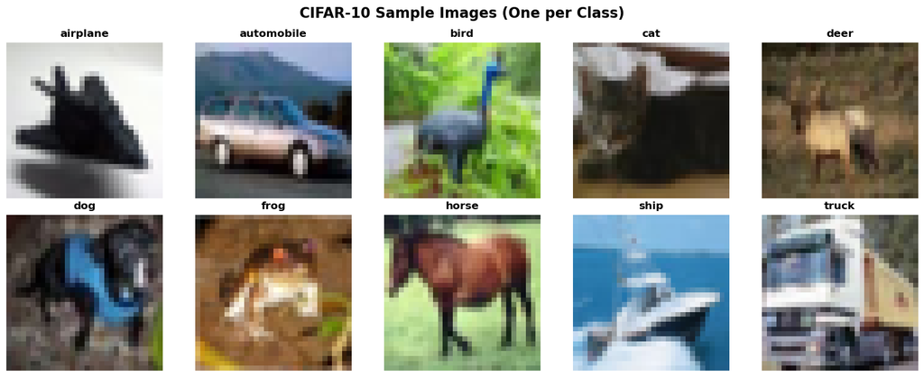

```python
# Load dataset without ImageNet normalization for visualization
viz_transform = transforms.Compose([transforms.ToTensor()])
viz_dataset = datasets.CIFAR10(root='./data', train=True, download=False, transform=viz_transform)

# Collect one sample per class
samples_per_class = {}
for img, label in viz_dataset:
    if label not in samples_per_class:
        samples_per_class[label] = img
    if len(samples_per_class) == 10:
        break

# Display samples
fig, axes = plt.subplots(2, 5, figsize=(15, 6))
fig.suptitle('CIFAR-10 Sample Images (One per Class)', fontsize=16, fontweight='bold')

for idx, (label, img) in enumerate(sorted(samples_per_class.items())):
    row, col = idx // 5, idx % 5
    axes[row, col].imshow(img.permute(1, 2, 0))
    axes[row, col].set_title(f'{CIFAR10_CLASSES[label]}', fontweight='bold')
    axes[row, col].axis('off')

plt.tight_layout()
plt.show()
```

#### Create Data Loaders

```python
# Create data loaders
batch_size = 64

train_loader = DataLoader(train_dataset, batch_size=batch_size,
                         shuffle=True, num_workers=2)
test_loader = DataLoader(test_dataset, batch_size=batch_size,
                        shuffle=False, num_workers=2)

print(f"Training batches: {len(train_loader)}")
print(f"Test batches: {len(test_loader)}")
print(f"Batch size: {batch_size}")
```

```
Training batches: 782
Test batches: 157
Batch size: 64
```

### Step 2: Load Pretrained ResNet-18 and Modify for CIFAR-10

```python
from tqdm.auto import tqdm

print("Loading pretrained ResNet-18 from ImageNet...")
resnet18_pretrained = models.resnet18(pretrained=True)

print("\nInspecting ResNet-18 architecture:")
print("="*60)

for name, child in tqdm(list(resnet18_pretrained.named_children()),
                        desc="ResNet-18 layers"):
    print(f"{name}: {child.__class__.__name__}")
    if name == "fc":  # Final fully connected layer
        print(f"  Input features: {child.in_features}")
        print(f"  Output features: {child.out_features} (ImageNet classes)")
```

```
Loading pretrained ResNet-18 from ImageNet...
```

```
Inspecting ResNet-18 architecture:
============================================================
```

```
conv1: Conv2d
bn1: BatchNorm2d
relu: ReLU
maxpool: MaxPool2d
layer1: Sequential
layer2: Sequential
layer3: Sequential
layer4: Sequential
avgpool: AdaptiveAvgPool2d
fc: Linear
  Input features: 512
  Output features: 1000 (ImageNet classes)
```

#### Replace Classification Head and Freeze Base Network

```python
# Freeze all parameters in the base network
print("Freezing all pretrained parameters...")
for param in resnet18_pretrained.parameters():
    param.requires_grad_(False)  # in-place, slightly more idiomatic

# Replace the final fully connected layer for CIFAR-10 (10 classes)
in_features = resnet18_pretrained.fc.in_features
resnet18_pretrained.fc = nn.Linear(in_features, 10)

print(f"\nReplaced fc layer: Linear({in_features}, 10)")
print("New classification head will be trained for CIFAR-10")

# Move model to device
resnet18_pretrained = resnet18_pretrained.to(device)

# Verify which parameters are trainable
total_params = sum(p.numel() for p in resnet18_pretrained.parameters())
trainable_params = sum(p.numel() for p in resnet18_pretrained.parameters()
                       if p.requires_grad)

print(f"\nTrainable parameters: {trainable_params:,}")
print(f"Total parameters: {total_params:,}")
print(f"Percentage trainable: {100 * trainable_params / total_params:.2f}%")
```

```
Freezing all pretrained parameters...

Replaced fc layer: Linear(512, 10)
New classification head will be trained for CIFAR-10

Trainable parameters: 5,130
Total parameters: 11,181,642
Percentage trainable: 0.05%
```

### Step 3: Training Setup

```python
# Define loss function and optimizer
# Only optimize parameters that require gradients (the new fc layer)
criterion = nn.CrossEntropyLoss()
optimizer = optim.Adam(filter(lambda p: p.requires_grad, resnet18_pretrained.parameters()),
                       lr=0.001)

print("Training configuration:")
print(f"  Loss function: CrossEntropyLoss")
print(f"  Optimizer: Adam")
print(f"  Learning rate: 0.001")
print(f"  Device: {device}")
```

```
Training configuration:
  Loss function: CrossEntropyLoss
  Optimizer: Adam
  Learning rate: 0.001
  Device: cpu
```

#### Define Training and Evaluation Functions

```python
def train_one_epoch(model, train_loader, criterion, optimizer, device):
    """Train the model for one epoch"""
    model.train()
    running_loss = 0.0
    correct = 0
    total = 0

    for batch_idx, (inputs, targets) in enumerate(train_loader):
        inputs, targets = inputs.to(device), targets.to(device)

        # Forward pass
        optimizer.zero_grad()
        outputs = model(inputs)
        loss = criterion(outputs, targets)

        # Backward pass
        loss.backward()
        optimizer.step()

        # Statistics
        running_loss += loss.item()
        _, predicted = outputs.max(1)
        total += targets.size(0)
        correct += predicted.eq(targets).sum().item()

        if (batch_idx + 1) % 100 == 0:
            print(f'  Batch [{batch_idx+1}/{len(train_loader)}], '
                  f'Loss: {running_loss/(batch_idx+1):.4f}, '
                  f'Acc: {100.*correct/total:.2f}%')

    epoch_loss = running_loss / len(train_loader)
    epoch_acc = 100. * correct / total
    return epoch_loss, epoch_acc


def evaluate(model, test_loader, criterion, device):
    """Evaluate the model on test set"""
    model.eval()
    running_loss = 0.0
    correct = 0
    total = 0

    with torch.no_grad():
        for inputs, targets in test_loader:
            inputs, targets = inputs.to(device), targets.to(device)
            outputs = model(inputs)
            loss = criterion(outputs, targets)

            running_loss += loss.item()
            _, predicted = outputs.max(1)
            total += targets.size(0)
            correct += predicted.eq(targets).sum().item()

    test_loss = running_loss / len(test_loader)
    test_acc = 100. * correct / total
    return test_loss, test_acc

print("Training and evaluation functions defined!")
```

```
Training and evaluation functions defined!
```

### Step 4: Train Transfer Learning Model

```python
# Train for exactly 1 epoch, log per-batch metrics
print("Training transfer learning model (1 epoch, batch-based logging)...")
print("Target: >= 70% test accuracy (but no early stop)")
print("="*60)

num_epochs = 1          # fixed to 1
best_acc = 0.0
global_step = 0

history = {
    'step': [],          # batch index
    'train_loss': [],    # batch-wise
    'train_acc': [],     # batch-wise
    'test_loss': [],     # per-epoch
    'test_acc': []       # per-epoch
}

for epoch in tqdm(range(num_epochs), desc="Epochs"):
    print(f"\nEpoch [{epoch+1}/{num_epochs}]")

    resnet18_pretrained.train()
    running_loss = 0.0
    correct = 0
    total = 0

    for batch_idx, (inputs, targets) in tqdm(enumerate(train_loader), desc="Training Batches", total=len(train_loader)):
        inputs, targets = inputs.to(device), targets.to(device)

        optimizer.zero_grad()
        outputs = resnet18_pretrained(inputs)
        loss = criterion(outputs, targets)
        loss.backward()
        optimizer.step()

        # batch stats
        _, predicted = outputs.max(1)
        batch_correct = predicted.eq(targets).sum().item()
        batch_total = targets.size(0)
        batch_acc = 100.0 * batch_correct / batch_total

        running_loss += loss.item()
        correct += batch_correct
        total += batch_total

        # log per batch
        global_step += 1
        history['step'].append(global_step)
        history['train_loss'].append(loss.item())
        history['train_acc'].append(batch_acc)

        if (batch_idx + 1) % 100 == 0:
            print(f"  Batch [{batch_idx+1}/{len(train_loader)}] | "
                  f"Loss: {running_loss/(batch_idx+1):.4f} | "
                  f"Acc: {100.*correct/total:.2f}%")

    # epoch-level stats
    train_loss = running_loss / len(train_loader)
    train_acc = 100.0 * correct / total

    # evaluate once at end of epoch
    test_loss, test_acc = evaluate(resnet18_pretrained, test_loader, criterion, device)

    history['test_loss'].append(test_loss)
    history['test_acc'].append(test_acc)

    print(f"\n  Train Loss: {train_loss:.4f}, Train Acc: {train_acc:.2f}%")
    print(f"  Test  Loss: {test_loss:.4f}, Test  Acc: {test_acc:.2f}%")

    if test_acc > best_acc:
        best_acc = test_acc
        torch.save(resnet18_pretrained.state_dict(), 'best_transfer_model.pth')
        print(f"  ✓ New best model saved! (Test Acc: {best_acc:.2f}%)")

print(f"\nTraining complete! Best test accuracy: {best_acc:.2f}%")
```

```
Training transfer learning model (1 epoch, batch-based logging)...
Target: >= 70% test accuracy (but no early stop)
============================================================
```

```
Epoch [1/1]
```

```
  Batch [100/782] | Loss: 1.4605 | Acc: 53.55%
  Batch [200/782] | Loss: 1.1885 | Acc: 62.96%
  Batch [300/782] | Loss: 1.0521 | Acc: 66.95%
  Batch [400/782] | Loss: 0.9692 | Acc: 69.25%
  Batch [500/782] | Loss: 0.9162 | Acc: 70.71%
  Batch [600/782] | Loss: 0.8750 | Acc: 71.86%
  Batch [700/782] | Loss: 0.8446 | Acc: 72.61%

  Train Loss: 0.8251, Train Acc: 73.11%
  Test  Loss: 0.6245, Test  Acc: 79.23%
  ✓ New best model saved! (Test Acc: 79.23%)

Training complete! Best test accuracy: 79.23%
```

#### Plot Training History

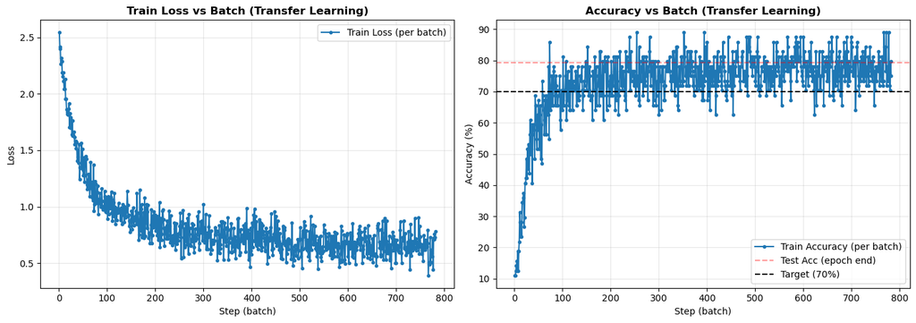

```python
# Plot training curves (batch-based)
fig, (ax1, ax2) = plt.subplots(1, 2, figsize=(14, 5))

# Plot batch-wise train loss
ax1.plot(history['step'], history['train_loss'],
         label='Train Loss (per batch)', marker='.', linestyle='-')
ax1.set_xlabel('Step (batch)')
ax1.set_ylabel('Loss')
ax1.set_title('Train Loss vs Batch (Transfer Learning)', fontweight='bold')
ax1.legend()
ax1.grid(True, alpha=0.3)

# Plot batch-wise train accuracy
ax2.plot(history['step'], history['train_acc'],
         label='Train Accuracy (per batch)', marker='.', linestyle='-')

# Optionally overlay epoch-level test accuracy as horizontal line(s)
for idx, test_acc in enumerate(history['test_acc']):
    ax2.axhline(y=test_acc, color='r', linestyle='--', alpha=0.4,
                label='Test Acc (epoch end)' if idx == 0 else None)

ax2.axhline(y=70, color='k', linestyle='--', label='Target (70%)')
ax2.set_xlabel('Step (batch)')
ax2.set_ylabel('Accuracy (%)')
ax2.set_title('Accuracy vs Batch (Transfer Learning)', fontweight='bold')
ax2.legend()
ax2.grid(True, alpha=0.3)

plt.tight_layout()
plt.show()
```

### Step 5: Per-Class Performance Analysis

```python
def compute_per_class_accuracy(model, test_loader, device, num_classes=10):
    """Compute accuracy for each class"""
    class_correct = [0] * num_classes
    class_total = [0] * num_classes

    model.eval()
    with torch.no_grad():
        for inputs, targets in tqdm(test_loader, desc="Evaluating"):
            inputs, targets = inputs.to(device), targets.to(device)
            outputs = model(inputs)
            _, predicted = outputs.max(1)

            for i in range(targets.size(0)):
                label = targets[i].item()
                class_correct[label] += (predicted[i] == targets[i]).item()
                class_total[label] += 1

    class_accuracies = {}
    for i in tqdm(range(num_classes), desc="Computing per-class accuracy"):
        acc = 100. * class_correct[i] / class_total[i] if class_total[i] > 0 else 0
        class_accuracies[i] = acc

    return class_accuracies

# Compute per-class accuracies
class_accs = compute_per_class_accuracy(resnet18_pretrained, test_loader, device)

print("Per-Class Accuracies:")
print("="*60)
for class_idx in range(10):
    print(f"{CIFAR10_CLASSES[class_idx]:12s}: {class_accs[class_idx]:.2f}%")

# Find best and worst 2 classes
sorted_classes = sorted(class_accs.items(), key=lambda x: x[1], reverse=True)
best_2 = sorted_classes[:2]
worst_2 = sorted_classes[-2:]

print("\n" + "="*60)
print("Best 2 Classes:")
for class_idx, acc in best_2:
    print(f"  {CIFAR10_CLASSES[class_idx]:12s}: {acc:.2f}%")

print("\nWorst 2 Classes:")
for class_idx, acc in worst_2:
    print(f"  {CIFAR10_CLASSES[class_idx]:12s}: {acc:.2f}%")
print("="*60)
```

```
Per-Class Accuracies:
============================================================
airplane    : 78.80%
automobile  : 86.20%
bird        : 71.40%
cat         : 76.10%
deer        : 72.00%
dog         : 67.20%
frog        : 86.60%
horse       : 78.70%
ship        : 88.80%
truck       : 86.50%

============================================================
Best 2 Classes:
  ship        : 88.80%
  frog        : 86.60%

Worst 2 Classes:
  bird        : 71.40%
  dog         : 67.20%
============================================================
```

#### Visualize Class Performance

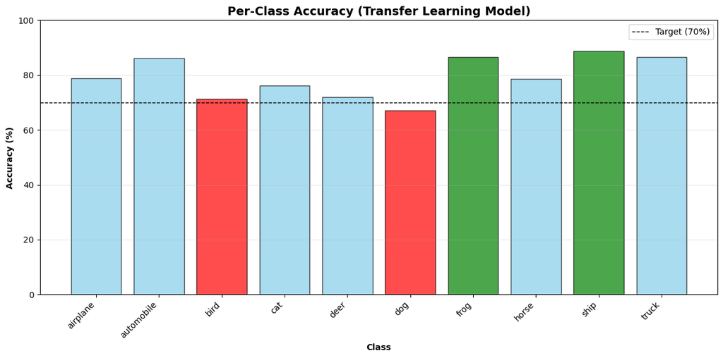

```python
# Bar chart of per-class accuracies
plt.figure(figsize=(12, 6))
classes = [CIFAR10_CLASSES[i] for i in range(10)]
accuracies = [class_accs[i] for i in range(10)]

colors = ['green' if i in [c[0] for c in best_2] else
          'red' if i in [c[0] for c in worst_2] else 'skyblue'
          for i in range(10)]

bars = plt.bar(classes, accuracies, color=colors, alpha=0.7, edgecolor='black')
plt.axhline(y=70, color='black', linestyle='--', linewidth=1, label='Target (70%)')
plt.xlabel('Class', fontweight='bold')
plt.ylabel('Accuracy (%)', fontweight='bold')
plt.title('Per-Class Accuracy (Transfer Learning Model)', fontsize=14, fontweight='bold')
plt.xticks(rotation=45, ha='right')
plt.ylim(0, 100)
plt.legend()
plt.grid(True, axis='y', alpha=0.3)
plt.tight_layout()
plt.show()
```

### Step 6: Find Top-10 High-Confidence Wrong Predictions

```python
def find_high_confidence_mistakes(model, test_loader, device, top_k=10):
    """Find top-k highest confidence wrong predictions"""
    model.eval()
    mistakes = []

    with torch.no_grad():
        for inputs, targets in test_loader:
            inputs, targets = inputs.to(device), targets.to(device)
            outputs = model(inputs)
            probs = torch.softmax(outputs, dim=1)
            confidences, predicted = probs.max(1)

            # Find wrong predictions
            wrong_mask = predicted != targets

            for i in range(inputs.size(0)):
                if wrong_mask[i]:
                    mistakes.append({
                        'image': inputs[i].cpu(),
                        'true_label': targets[i].item(),
                        'predicted_label': predicted[i].item(),
                        'confidence': confidences[i].item()
                    })

    # Sort by confidence (descending) and take top-k
    mistakes.sort(key=lambda x: x['confidence'], reverse=True)
    return mistakes[:top_k]

# Find top-10 high-confidence mistakes
print("Finding top-10 highest-confidence wrong predictions...")
top_mistakes = find_high_confidence_mistakes(resnet18_pretrained, test_loader, device, top_k=10)

print(f"Found {len(top_mistakes)} high-confidence mistakes")
print("\nTop-10 Mistakes:")
print("="*60)
for i, mistake in tqdm(enumerate(top_mistakes), desc="Top Mistakes"):
    true_class = CIFAR10_CLASSES[mistake['true_label']]
    pred_class = CIFAR10_CLASSES[mistake['predicted_label']]
    conf = mistake['confidence'] * 100
    print(f"{i+1}. True: {true_class:12s} | Predicted: {pred_class:12s} | Confidence: {conf:.2f}%")
```

```
Finding top-10 highest-confidence wrong predictions...
Found 10 high-confidence mistakes

Top-10 Mistakes:
============================================================
```

```
Top Mistakes: 0it [00:00, ?it/s]
```

```
1. True: airplane     | Predicted: ship         | Confidence: 99.94%
2. True: cat          | Predicted: frog         | Confidence: 99.40%
3. True: bird         | Predicted: deer         | Confidence: 99.05%
4. True: airplane     | Predicted: ship         | Confidence: 98.58%
5. True: deer         | Predicted: frog         | Confidence: 98.51%
6. True: dog          | Predicted: cat          | Confidence: 98.47%
7. True: truck        | Predicted: automobile   | Confidence: 98.47%
8. True: truck        | Predicted: automobile   | Confidence: 98.32%
9. True: frog         | Predicted: bird         | Confidence: 98.24%
10. True: airplane     | Predicted: ship         | Confidence: 98.21%
```

#### Visualize High-Confidence Mistakes

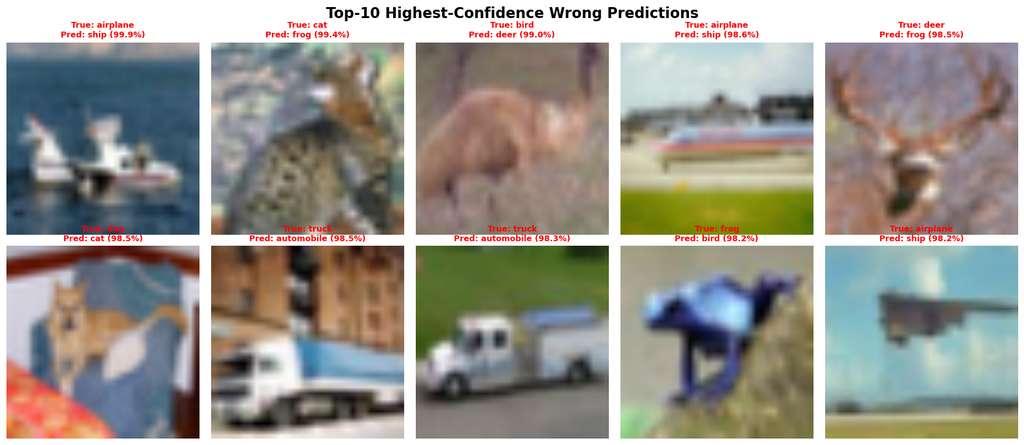

```python
# Denormalize function for visualization
def denormalize(tensor, mean=[0.485, 0.456, 0.406], std=[0.229, 0.224, 0.225]):
    """Denormalize image tensor for visualization"""
    img = tensor.clone()
    for t, m, s in zip(img, mean, std):
        t.mul_(s).add_(m)
    return torch.clamp(img, 0, 1)

# Display top-10 mistakes
fig, axes = plt.subplots(2, 5, figsize=(16, 7))
fig.suptitle('Top-10 Highest-Confidence Wrong Predictions', fontsize=16, fontweight='bold')

for idx, mistake in enumerate(top_mistakes):
    row, col = idx // 5, idx % 5

    # Denormalize and prepare image
    img = denormalize(mistake['image'])
    img_np = img.permute(1, 2, 0).numpy()

    # Get labels
    true_class = CIFAR10_CLASSES[mistake['true_label']]
    pred_class = CIFAR10_CLASSES[mistake['predicted_label']]
    conf = mistake['confidence'] * 100

    # Display
    axes[row, col].imshow(img_np)
    axes[row, col].set_title(f"True: {true_class}\nPred: {pred_class} ({conf:.1f}%)",
                            fontsize=9, color='red', fontweight='bold')
    axes[row, col].axis('off')

plt.tight_layout()
plt.show()
```

### Step 7: Train Non-Pretrained ResNet-18 for Comparison

```python
# Load ResNet-18 without pretrained weights
print("Loading ResNet-18 without pretrained weights...")
resnet18_new = models.resnet18(pretrained=False)

# Replace final layer for CIFAR-10
resnet18_new.fc = nn.Linear(resnet18_new.fc.in_features, 10)
resnet18_new = resnet18_new.to(device)

# Use same optimizer and loss
optimizer_new = optim.Adam(resnet18_new.parameters(), lr=0.001)
criterion_new = nn.CrossEntropyLoss()

# Count parameters
total_params_new = sum(p.numel() for p in resnet18_new.parameters())
trainable_params_new = sum(p.numel() for p in resnet18_new.parameters() if p.requires_grad)

print(f"\nNon-pretrained model:")
print(f"  Total parameters: {total_params_new:,}")
print(f"  Trainable parameters: {trainable_params_new:,}")
print(f"  All parameters will be trained from scratch!")
```

```
Loading ResNet-18 without pretrained weights...
```

```
Non-pretrained model:
  Total parameters: 11,181,642
  Trainable parameters: 11,181,642
  All parameters will be trained from scratch!
```

#### Train Non-Pretrained Model

```python
# Train non-pretrained model
print("Training non-pretrained ResNet-18...")
print("Single epoch (no early stopping)")
print("="*60)

num_epochs_new = 1
best_acc_new = 0.0
history_new = {'train_loss': [], 'train_acc': [], 'test_loss': [], 'test_acc': []}

for epoch in tqdm(range(num_epochs_new), desc="Training non-pretrained model"):
    print(f"\nEpoch [{epoch+1}/{num_epochs_new}]")

    # Train (epoch-level stats)
    train_loss, train_acc = train_one_epoch(
        resnet18_new, train_loader, criterion_new, optimizer_new, device
    )

    # Evaluate (epoch-level stats)
    test_loss, test_acc = evaluate(
        resnet18_new, test_loader, criterion_new, device
    )

    # Store history (per epoch)
    history_new['train_loss'].append(train_loss)
    history_new['train_acc'].append(train_acc)
    history_new['test_loss'].append(test_loss)
    history_new['test_acc'].append(test_acc)

    # Print summary
    print(f"\n  Train Loss: {train_loss:.4f}, Train Acc: {train_acc:.2f}%")
    print(f"  Test Loss:  {test_loss:.4f}, Test Acc:  {test_acc:.2f}%")

    # Save best model
    if test_acc > best_acc_new:
        best_acc_new = test_acc
        torch.save(resnet18_new.state_dict(), 'best_new_model.pth')
        print(f"  ✓ New best model saved! (Test Acc: {best_acc_new:.2f}%)")

print(f"\nTraining complete! Best test accuracy: {best_acc_new:.2f}%")
```

```
Training non-pretrained ResNet-18...
Single epoch (no early stopping)
============================================================
```

```
Epoch [1/1]
  Batch [100/782], Loss: 1.8775, Acc: 30.45%
  Batch [200/782], Loss: 1.7345, Acc: 35.66%
  Batch [300/782], Loss: 1.6430, Acc: 39.07%
  Batch [400/782], Loss: 1.5577, Acc: 42.47%
  Batch [500/782], Loss: 1.4861, Acc: 45.26%
  Batch [600/782], Loss: 1.4284, Acc: 47.58%
  Batch [700/782], Loss: 1.3779, Acc: 49.65%

  Train Loss: 1.3357, Train Acc: 51.33%
  Test Loss:  1.2388, Test Acc:  57.49%
  ✓ New best model saved! (Test Acc: 57.49%)

Training complete! Best test accuracy: 57.49%
```

```python
import torch
import torch.nn as nn
import torch.nn.functional as F

class ResidualDownBlock(nn.Module):
    """
    Residual block that reduces spatial resolution when stride=2.
    Main path: Conv3x3(stride) -> BN -> ReLU -> Conv3x3 -> BN
    Skip path: Conv1x1(stride) -> BN (projection to match shape)
    Output: ReLU(main + skip)
    """
    def __init__(self, in_ch, out_ch, stride=2):
        super().__init__()
        self.conv1 = nn.Conv2d(in_ch, out_ch, kernel_size=3, stride=stride, padding=1, bias=False)
        self.bn1   = nn.BatchNorm2d(out_ch)
        self.conv2 = nn.Conv2d(out_ch, out_ch, kernel_size=3, stride=1, padding=1, bias=False)
        self.bn2   = nn.BatchNorm2d(out_ch)

        self.proj = nn.Sequential(
            nn.Conv2d(in_ch, out_ch, kernel_size=1, stride=stride, bias=False),
            nn.BatchNorm2d(out_ch)
        )

    def forward(self, x):
        identity = self.proj(x)
        out = F.relu(self.bn1(self.conv1(x)))
        out = self.bn2(self.conv2(out))
        out = F.relu(out + identity)
        return out


class ThreeBlockResNet(nn.Module):
    """
    Input: (B, 3, 224, 224)  [same as ImageNet-style preprocessing]
    Stem -> 3 residual down blocks -> AdaptiveAvgPool -> Linear(10)
    """
    def __init__(self, num_classes=10, base_width=64):
        super().__init__()

        self.stem = nn.Sequential(
            nn.Conv2d(3, base_width, kernel_size=7, stride=2, padding=3, bias=False),  # 224 -> 112
            nn.BatchNorm2d(base_width),
            nn.ReLU(inplace=True),
            nn.MaxPool2d(kernel_size=3, stride=2, padding=1)  # 112 -> 56
        )

        self.block1 = ResidualDownBlock(base_width,   base_width*2, stride=2)  # 56 -> 28
        self.block2 = ResidualDownBlock(base_width*2, base_width*4, stride=2)  # 28 -> 14
        self.block3 = ResidualDownBlock(base_width*4, base_width*8, stride=2)  # 14 -> 7

        self.pool = nn.AdaptiveAvgPool2d((1, 1))
        self.head = nn.Linear(base_width*8, num_classes)

    def forward(self, x):
        x = self.stem(x)
        x = self.block1(x)
        x = self.block2(x)
        x = self.block3(x)
        x = self.pool(x)
        x = torch.flatten(x, 1)
        x = self.head(x)
        return x
```

```python
# Build NEW model from scratch (3 residual down blocks as required)
print("Building NEW model (3 residual down blocks) WITHOUT pretrained weights...")
new_model = ThreeBlockResNet(num_classes=10, base_width=64).to(device)

# Optimizer and loss (train all parameters)
optimizer_new = optim.Adam(new_model.parameters(), lr=0.001)
criterion_new = nn.CrossEntropyLoss()

# Count parameters
total_params_new = sum(p.numel() for p in new_model.parameters())
trainable_params_new = sum(p.numel() for p in new_model.parameters() if p.requires_grad)

print(f"\nNon-pretrained (custom) model:")
print(f"  Total parameters: {total_params_new:,}")
print(f"  Trainable parameters: {trainable_params_new:,}")
print(f"  All parameters will be trained from scratch!")
```

```
Building NEW model (3 residual down blocks) WITHOUT pretrained weights...

Non-pretrained (custom) model:
  Total parameters: 4,836,938
  Trainable parameters: 4,836,938
  All parameters will be trained from scratch!
```

```python
TARGET_ACC = 70.0
MAX_EPOCHS_NEW = 30  # increase if needed (e.g., 50). This is just a safety cap.

print("Training non-pretrained model...")
print(f"Train until test accuracy >= {TARGET_ACC:.0f}% (early stopping).")
print("=" * 60)

best_acc_new = 0.0
best_epoch_new = None

history_new = {'train_loss': [], 'train_acc': [], 'test_loss': [], 'test_acc': []}

def train_one_epoch_with_tqdm(model, loader, criterion, optimizer, device, epoch_idx, max_epochs):
    model.train()
    running_loss = 0.0
    correct = 0
    total = 0

    pbar = tqdm(loader, desc=f"Epoch {epoch_idx}/{max_epochs} | Train", leave=False)
    for images, labels in pbar:
        images = images.to(device, non_blocking=True)
        labels = labels.to(device, non_blocking=True)

        optimizer.zero_grad(set_to_none=True)
        outputs = model(images)
        loss = criterion(outputs, labels)
        loss.backward()
        optimizer.step()

        bs = labels.size(0)
        running_loss += loss.item() * bs
        _, preds = outputs.max(dim=1)
        correct += (preds == labels).sum().item()
        total += bs

        pbar.set_postfix({
            "loss": f"{(running_loss / total):.4f}",
            "acc%": f"{(100.0 * correct / total):.2f}"
        })

    return (running_loss / total), (100.0 * correct / total)

for epoch in range(1, MAX_EPOCHS_NEW + 1):
    print(f"\nEpoch [{epoch}/{MAX_EPOCHS_NEW}]")

    # Train (batch-level tqdm inside)
    train_loss, train_acc = train_one_epoch_with_tqdm(new_model, train_loader, criterion_new, optimizer_new, device, epoch, MAX_EPOCHS_NEW)

    # Evaluate (your existing function)
    test_loss, test_acc = evaluate(new_model, test_loader, criterion_new, device)

    # Store history
    history_new['train_loss'].append(train_loss)
    history_new['train_acc'].append(train_acc)
    history_new['test_loss'].append(test_loss)
    history_new['test_acc'].append(test_acc)

    # Print summary (your style)
    print(f"\n  Train Loss: {train_loss:.4f}, Train Acc: {train_acc:.2f}%")
    print(f"  Test Loss:  {test_loss:.4f}, Test Acc:  {test_acc:.2f}%")

    # Save best model
    if test_acc > best_acc_new:
        best_acc_new = test_acc
        best_epoch_new = epoch
        torch.save(new_model.state_dict(), "best_new_model.pth")
        print(f"  ✓ New best model saved! (Test Acc: {best_acc_new:.2f}%)")

    # Early stop when reaching target
    if test_acc >= TARGET_ACC:
        print(f"\n✓ Target reached: Test Acc {test_acc:.2f}% >= {TARGET_ACC:.0f}% at epoch {epoch}")
        break

print("\nTraining complete!")
print(f"Best test accuracy: {best_acc_new:.2f}% (epoch {best_epoch_new})")
```

```
Training non-pretrained model...
Train until test accuracy >= 70% (early stopping).
============================================================

Epoch [1/30]
```

```
  Train Loss: 1.3700, Train Acc: 50.08%
  Test Loss:  1.2853, Test Acc:  53.60%
  ✓ New best model saved! (Test Acc: 53.60%)

Epoch [2/30]
```

```
  Train Loss: 0.9243, Train Acc: 67.10%
  Test Loss:  0.9323, Test Acc:  67.19%
  ✓ New best model saved! (Test Acc: 67.19%)

Epoch [3/30]
```

```
  Train Loss: 0.7168, Train Acc: 74.95%
  Test Loss:  1.0453, Test Acc:  65.78%

Epoch [4/30]
```

```
  Train Loss: 0.5753, Train Acc: 79.93%
  Test Loss:  0.6514, Test Acc:  77.04%
  ✓ New best model saved! (Test Acc: 77.04%)

✓ Target reached: Test Acc 77.04% >= 70% at epoch 4

Training complete!
Best test accuracy: 77.04% (epoch 4)
```

### Step 8: Compare Transfer Learning vs Non-Pretrained Models

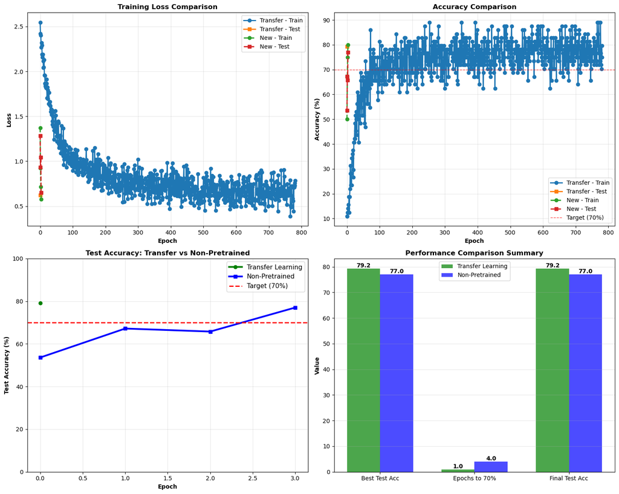

```python
# Comparison plots (unchanged, still epoch-based)
fig, ((ax1, ax2), (ax3, ax4)) = plt.subplots(2, 2, figsize=(15, 12))

# Plot 1: Loss comparison
ax1.plot(history['train_loss'], label='Transfer - Train', marker='o', linewidth=2)
ax1.plot(history['test_loss'], label='Transfer - Test', marker='s', linewidth=2)
ax1.plot(history_new['train_loss'], label='New - Train', marker='o', linewidth=2, linestyle='--')
ax1.plot(history_new['test_loss'], label='New - Test', marker='s', linewidth=2, linestyle='--')
ax1.set_xlabel('Epoch', fontweight='bold')
ax1.set_ylabel('Loss', fontweight='bold')
ax1.set_title('Training Loss Comparison', fontsize=12, fontweight='bold')
ax1.legend()
ax1.grid(True, alpha=0.3)

# Plot 2: Accuracy comparison
ax2.plot(history['train_acc'], label='Transfer - Train', marker='o', linewidth=2)
ax2.plot(history['test_acc'], label='Transfer - Test', marker='s', linewidth=2)
ax2.plot(history_new['train_acc'], label='New - Train', marker='o', linewidth=2, linestyle='--')
ax2.plot(history_new['test_acc'], label='New - Test', marker='s', linewidth=2, linestyle='--')
ax2.axhline(y=70, color='r', linestyle='--', linewidth=1, alpha=0.7, label='Target (70%)')
ax2.set_xlabel('Epoch', fontweight='bold')
ax2.set_ylabel('Accuracy (%)', fontweight='bold')
ax2.set_title('Accuracy Comparison', fontsize=12, fontweight='bold')
ax2.legend()
ax2.grid(True, alpha=0.3)

# Plot 3: Test accuracy only (clearer view)
ax3.plot(history['test_acc'], label='Transfer Learning', marker='o', linewidth=3, color='green')
ax3.plot(history_new['test_acc'], label='Non-Pretrained', marker='s', linewidth=3, color='blue')
ax3.axhline(y=70, color='r', linestyle='--', linewidth=2, label='Target (70%)')
ax3.set_xlabel('Epoch', fontweight='bold')
ax3.set_ylabel('Test Accuracy (%)', fontweight='bold')
ax3.set_title('Test Accuracy: Transfer vs Non-Pretrained', fontsize=12, fontweight='bold')
ax3.legend(fontsize=11)
ax3.grid(True, alpha=0.3)
ax3.set_ylim(0, 100)

# Plot 4: Summary statistics
categories = ['Best Test Acc', 'Epochs to 70%', 'Final Test Acc']
transfer_stats = [
    best_acc,
    len(history['test_acc']),        # Epochs trained (transfer)
    history['test_acc'][-1]
]
new_stats = [
    best_acc_new,
    len(history_new['test_acc']),    # Epochs trained (non-pretrained)
    history_new['test_acc'][-1]
]

x = np.arange(len(categories))
width = 0.35

bars1 = ax4.bar(x - width/2, transfer_stats, width, label='Transfer Learning', color='green', alpha=0.7)
bars2 = ax4.bar(x + width/2, new_stats, width, label='Non-Pretrained', color='blue', alpha=0.7)

ax4.set_ylabel('Value', fontweight='bold')
ax4.set_title('Performance Comparison Summary', fontsize=12, fontweight='bold')
ax4.set_xticks(x)
ax4.set_xticklabels(categories)
ax4.legend()
ax4.grid(True, axis='y', alpha=0.3)

for bars in [bars1, bars2]:
    for bar in bars:
        height = bar.get_height()
        ax4.text(bar.get_x() + bar.get_width()/2., height,
                 f'{height:.1f}',
                 ha='center', va='bottom', fontweight='bold')

plt.tight_layout()
plt.show()
```

#### Detailed Comparison Summary

```python
print("="*70)
print("TRANSFER LEARNING vs NON-PRETRAINED MODEL COMPARISON")
print("="*70)

print("\n TRANSFER LEARNING MODEL (Pretrained ResNet-18)")
print("-" * 70)
print(f"Best Test Accuracy:        {best_acc:.2f}%")
print(f"Final Test Accuracy:       {history['test_acc'][-1]:.2f}%")
print(f"Epochs to reach target:    {len(history['test_acc'])}")
print(f"Trainable parameters:      {trainable_params:,} ({100*trainable_params/total_params:.2f}%)")
print(f"Training strategy:         Only final FC layer trained")

print("\n NON-PRETRAINED MODEL (From Scratch)")
print("-" * 70)
print(f"Best Test Accuracy:        {best_acc_new:.2f}%")
print(f"Final Test Accuracy:       {history_new['test_acc'][-1]:.2f}%")
print(f"Epochs to reach target:    {len(history_new['test_acc'])}")
print(f"Trainable parameters:      {trainable_params_new:,} (100%)")
print(f"Training strategy:         All layers trained from scratch")

print("\n KEY INSIGHTS")
print("-" * 70)

# Calculate differences
acc_diff = best_acc - best_acc_new
epoch_diff = len(history_new['test_acc']) - len(history['test_acc'])
param_ratio = trainable_params / trainable_params_new

print(f"✓ Transfer learning achieved {acc_diff:.2f}% higher accuracy")
print(f"✓ Transfer learning reached target {epoch_diff} epochs faster" if epoch_diff > 0
      else f"✓ Transfer learning reached target in fewer epochs")
print(f"✓ Transfer learning trained {100*param_ratio:.2f}% of parameters")
print(f"✓ Transfer learning benefits from ImageNet pretrained features")
print(f"✓ Non-pretrained model learns all features from CIFAR-10 alone")

print("\n" + "="*70)
```

```
======================================================================
TRANSFER LEARNING vs NON-PRETRAINED MODEL COMPARISON
======================================================================

 TRANSFER LEARNING MODEL (Pretrained ResNet-18)
----------------------------------------------------------------------
Best Test Accuracy:        79.23%
Final Test Accuracy:       79.23%
Epochs to reach target:    1
Trainable parameters:      5,130 (0.05%)
Training strategy:         Only final FC layer trained

 NON-PRETRAINED MODEL (From Scratch)
----------------------------------------------------------------------
Best Test Accuracy:        77.04%
Final Test Accuracy:       77.04%
Epochs to reach target:    4
Trainable parameters:      4,836,938 (100%)
Training strategy:         All layers trained from scratch

 KEY INSIGHTS
----------------------------------------------------------------------
✓ Transfer learning achieved 2.19% higher accuracy
✓ Transfer learning reached target 3 epochs faster
✓ Transfer learning trained 0.11% of parameters
✓ Transfer learning benefits from ImageNet pretrained features
✓ Non-pretrained model learns all features from CIFAR-10 alone

======================================================================
```

### Question 3 – Training and Evaluating a Custom Residual Network from Scratch

In this question, a new convolutional neural network was designed and trained from scratch, following a residual architecture composed of three residual blocks that progressively reduce the spatial resolution of the feature maps. The model was constructed to accept the same input format as the transfer learning model, ensuring comparability between the two approaches. An adaptive average pooling layer was applied before a linear classification head, resulting in a compact yet expressive architecture tailored to the CIFAR-10 task.

The primary motivation behind this experiment was to evaluate how a residual network behaves when trained without pretrained weights, and to assess the extent to which residual connections alone can facilitate effective optimization. By restricting the architecture to three residual blocks, the model maintains the core principles of residual learning while significantly reducing depth and parameter count compared to standard architectures such as ResNet-18. This design choice aimed to balance computational efficiency with representational capacity.

This experiment highlights both the feasibility and the cost of training residual networks from scratch. While the model required more epochs and significantly more trainable parameters than the transfer learning approach, it was nevertheless able to learn discriminative features directly from the CIFAR-10 data. The results demonstrate that, given a well-designed residual architecture, competitive performance can be achieved without relying on pretrained representations, albeit with increased training effort.

# Assignment Summary

This assignment provided a comprehensive investigation of convolutional neural networks and residual architectures, combining low-level implementation, transfer learning, and custom model design. The work began with the manual implementation of a convolution layer, which established a concrete understanding of the fundamental operations underlying modern CNNs and clarified the relationship between theoretical definitions and practical computation.

Building on this foundation, transfer learning was applied using a pretrained ResNet-18 model. By freezing the pretrained backbone and training only the final classification layer, the model rapidly achieved strong performance, reaching a best test accuracy of **79.23%** after a single epoch. This result illustrates the effectiveness of leveraging pretrained representations and demonstrates how transfer learning can drastically reduce both training time and the number of parameters that need to be optimized.

Overall, the assignment emphasizes key trade-offs in deep learning model design, including performance, training efficiency, and reliance on external data. Transfer learning emerged as the preferred approach in terms of accuracy and computational efficiency, while the custom residual model demonstrated the capacity to learn meaningful representations independently. Together, these experiments provide a holistic perspective on convolutional and residual networks, reinforcing both their practical advantages and their underlying theoretical principles.